# Problem Set 1 - Andreas Bloch

This is the problem set submission of Andreas Bloch (abloch@student.ethz.ch)

## Imports

First we'll load some libraries and scripts that will be useful throughout the entire notebook.

```python
import os

%matplotlib inline
import matplotlib.pyplot as plt

from collections import Counter

import itertools

from nltk.sentiment.vader import SentimentIntensityAnalyzer
from nltk.stem import SnowballStemmer

import numpy as np

import pandas as pd

import re

import seaborn as sns

from sklearn.cluster import KMeans
from sklearn.feature_extraction.text import TfidfVectorizer
from sklearn.linear_model import LogisticRegression
from sklearn.metrics import accuracy_score
from sklearn.metrics import f1_score
from sklearn.metrics import roc_auc_score
from sklearn.metrics import roc_curve
from sklearn.metrics.pairwise import cosine_similarity
from sklearn.model_selection import train_test_split
from sklearn.model_selection import GridSearchCV
from sklearn.model_selection import cross_val_predict
from sklearn.preprocessing import StandardScaler
from sklearn.utils import shuffle

import spacy
from spacy.lang.en.stop_words import STOP_WORDS
from spacy.lemmatizer import Lemmatizer
from spacy.lang.en import LEMMA_INDEX, LEMMA_EXC, LEMMA_RULES

from string import punctuation

import swifter
```

## Reading of Data

Next we'll read the data from disk into a pandas data frame.

```python
# define data locations
DATA_DIR = './data'
CASE_DIR = './data/cases'
REVERSED_CASES = 'case_reversed.csv'

# read reversal decisions from CSV
case_reversed_csv = pd.read_csv(os.path.join(DATA_DIR, REVERSED_CASES))

# create data frame to combine the data sources
reversal_case_ids = case_reversed_csv['caseid'].values
columns = ['year', 'text', 'doc', 'reversed',
           'num_sentences', 'num_words', 'num_letters',
           'num_nouns', 'num_verbs', 'num_adjectives',
           'trigrams']

data = pd.DataFrame(
    index=pd.Index(reversal_case_ids, name='case_id'),
    columns=pd.Index(columns, name='attributes')
)

# store reversal decisions into data frame
for idx, row in case_reversed_csv.iterrows():
    case_id = row[0]
    reversed = row[1]
    data.at[case_id, 'reversed'] = reversed

# read and store case txt files into data frame
case_ids = []
for file in os.listdir(os.fsencode(CASE_DIR)):
    filename = os.fsdecode(file)
    file_handle = open(os.path.join(CASE_DIR, filename), 'r')

    year = filename.partition('_')[0]
    case_id = filename.partition('_')[2].partition('.')[0]
    text = file_handle.read()

    case_ids.append(case_id)

    data.at[case_id, 'year'] = year
    data.at[case_id, 'text'] = text

# data integrity check:
# check that every case has a matching reversal decision and vice-versa
if set(case_ids) != set(reversal_case_ids):
    raise Exception('case_ids not matching! check loading of data!')

# set data types
data[['year']] = data[['year']].astype(int)
data[['reversed']] = data[['reversed']].astype(float)
data[['num_sentences']] = data[['num_sentences']].astype(float)
data[['num_words']] = data[['num_words']].astype(float)
data[['num_letters']] = data[['num_letters']].astype(float)
data[['num_nouns']] = data[['num_nouns']].astype(float)
data[['num_verbs']] = data[['num_verbs']].astype(float)
data[['num_adjectives']] = data[['num_adjectives']].astype(float)

# print data types
print('Dataframe Data Types:')
data.dtypes
```

```
Dataframe Data Types:
```

```
attributes
year                int64
text               object
doc                object
reversed          float64
num_sentences     float64
num_words         float64
num_letters       float64
num_nouns         float64
num_verbs         float64
num_adjectives    float64
trigrams           object
dtype: object
```

```python
# print preview of data to show that it's loaded
print('Dataframe Data:')
data.head()
```

```
Dataframe Data:
```

| attributes case_id | year | text | doc | reversed | num_sentences | num_words | num_letters | num_nouns | num_verbs | num_adjectives | trigrams |
| --- | --- | --- | --- | --- | --- | --- | --- | --- | --- | --- | --- |
| X3JGGO | 1925 | POLLOCK , District Judge.\nFor convenience, t... | NaN | 0.0 | NaN | NaN | NaN | NaN | NaN | NaN | NaN |
| X3OH3J | 1924 | JOHNSON , Circuit Judge.\nThis is a patent in... | NaN | 0.0 | NaN | NaN | NaN | NaN | NaN | NaN | NaN |
| X3U0KO | 1925 | WOOLLEY , Circuit Judge.\nThe indictment agai... | NaN | 0.0 | NaN | NaN | NaN | NaN | NaN | NaN | NaN |
| X53HAD | 1924 | ROGERS , Circuit Judge.\nThe complainant is a... | NaN | 0.0 | NaN | NaN | NaN | NaN | NaN | NaN | NaN |
| X9VC5V | 1925 | DAWKINS , District Judge.\nComplainant brough... | NaN | 0.0 | NaN | NaN | NaN | NaN | NaN | NaN | NaN |

```python
# print data frame dimensions
print('Dataframe Dimensions:')
data.shape
```

```
Dataframe Dimensions:
```

```
(5762, 11)
```

## Shuffling of Data

Shuffle the data to make sure we have positive and negative reversal examples.

```python
data = shuffle(data, random_state=23)
```

## Optional: Subsampling of Data

Execute this code if you want to subsample your data.

```python
SUBSAMPLE = True         # set this to True if you want to subsample your data for performance reasons
SUBSAMPLING_SIZE = 1000
```

```python
if SUBSAMPLE:
    data = data.head(SUBSAMPLING_SIZE)
```

## Exercise 1

**Q:** Use spaCy to process all cases. Split the documents into sentences and tokens. Compute number of sentences, words, and letters for each document. Report histograms for these statistics.

```python
nlp = spacy.load('en')

# do NLP with spacy on documents
data['doc'] = data['text'].swifter.apply(nlp)

# count number of sentences, words and letters
data['num_sentences'] = data['doc'].swifter.apply(
    lambda doc: len(list(doc.sents))
)
data['num_words'] = data['doc'].swifter.apply(
    lambda doc: len(doc)
)
data['num_letters'] = data['text'].swifter.apply(
    lambda text: len(''.join(filter(str.isalpha, text)))
)
```

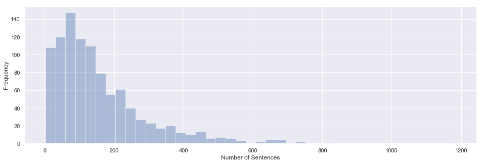

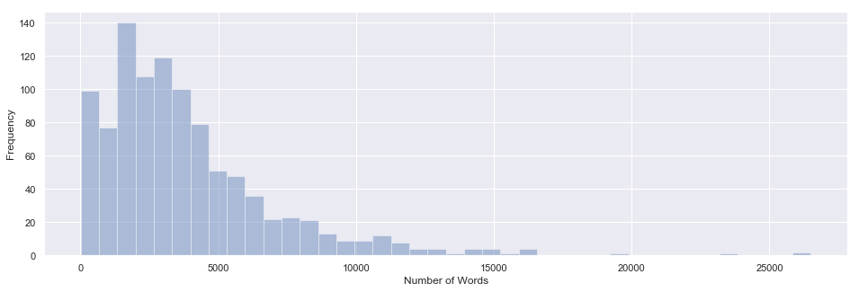

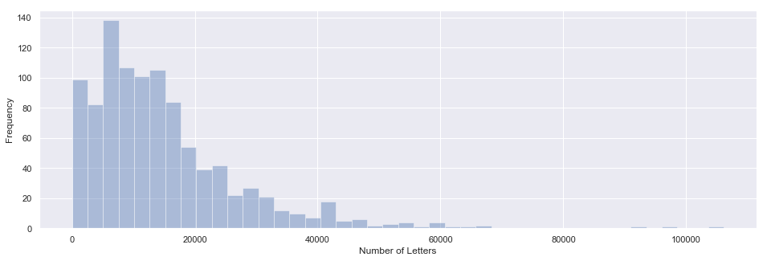

```python
# use wide figures across whole document
sns.set(rc={'figure.figsize':(16,5)})

# plot sentence frequencies
ax = sns.distplot(data['num_sentences'].values, kde=False)
ax.set(xlabel='Number of Sentences', ylabel='Frequency')
plt.show()

# plot word frequencies
ax = sns.distplot(data['num_words'].values, kde=False)
ax.set(xlabel='Number of Words', ylabel='Frequency')
plt.show()

# plot letter frequencies
ax = sns.distplot(data['num_letters'].values, kde=False)
ax.set(xlabel='Number of Letters', ylabel='Frequency')
plt.show()
```

## Exercise 2

**Q:** Use the spaCy parts of speech (POS) tags to count number of nouns, verbs, and adjectives in each document. Visualize POS frequency by year.

**A:** See here if you want a more detailed explanation of spacy.parts_of_speech symbols:

https://universaldependencies.org/u/pos/all.html

I've decided not to count proper nouns (PROPN) as nouns.

```python
# count number of nouns, verbs and adjectives (through POS tags)
data['num_nouns'] = data['doc'].swifter.apply(
    lambda doc: sum(token.pos == spacy.parts_of_speech.NOUN for token in doc)
)
data['num_verbs'] = data['doc'].swifter.apply(
    lambda doc: sum(token.pos == spacy.parts_of_speech.VERB for token in doc)
)
data['num_adjectives'] = data['doc'].swifter.apply(
    lambda doc: sum(token.pos == spacy.parts_of_speech.ADJ for token in doc)
)
```

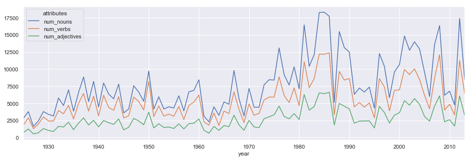

```python
data.groupby('year')['num_nouns','num_verbs','num_adjectives'].sum().plot.line()
```

## Exercise 3

**Q:** Follow the steps in lecture to normalize your corpus (e.g., removing punctuation) and discuss your choices about what information to exclude. Using the normalized tokens, make a feature set of all trigrams that end in a noun.

**A:** The steps are explained in the comments in the code below. The feature set will be stored in the column data['trigrams'].

```python
# jthe list of stop words used by spacy can be found in the imports above.
# i've decided not to add or remove any stop words from this list as they
# seem to be fine.
print('Used Stop Words:')
print(STOP_WORDS)

# create punctuation remover
punctuation_remover = str.maketrans('', '', punctuation)

# create lemmatizer
lemmatizer = Lemmatizer(LEMMA_INDEX, LEMMA_EXC, LEMMA_RULES)

# create snowball stemmer
stemmer = SnowballStemmer('english')

# function to normalize a doc
def normalize_text_and_create_trigrams(doc):

    # list of found normalized 3-grams in doc
    trigrams = []

    # process sent. by sent. to avoid creating n-grams that overlap a sent.
    for sentence in doc.sents:

        words = []  # words in sentence
        poses = []  # POSes of words in sentence

        # filter out unwanted tokens and normalize the kept tokens
        for token in sentence:
            # get the token's word(s)
            word = ''.join(token.text)
            # replace newlines with spaces
            word = word.replace('\r', ' ').replace('\n', ' ')
            # remove punctuation
            word = word.translate(punctuation_remover)
            # replace multiple subsequent spaces with one space
            word = re.sub(' +', ' ', word)
            # check that word still has some text (not just one char or space)
            if len(word) <= 1:
                continue
            # normalize numbers (28, 28th, 1st, ...)
            if any(char.isdigit() for char in word):
                word = '#'
            # lemmatize the word
            lemmas = lemmatizer(word, token.pos)[0]
            if isinstance(lemmas, (list,)) and len(lemmas) > 0:
                # pick the first option if several lemmas were found
                word = lemmas[0]
            else:
                # no lemma was found (just keep the original word)
                word = word
            # convert the word to lowercase
            word = word.lower()
            # remove stopwords
            # this check has to be done at the end because some words aren't
            # a stop-word in their unlemmatized form. Further note that
            # token.is_stop didn't use all the words from STOP_WORDS, so it's
            # better to check against the full list again.
            if word in STOP_WORDS:
                continue
            # stem the word to remove singular/plural
            word = stemmer.stem(word)
            # keep track of the token's word and pos tag
            words.append(word)
            poses.append(token.pos)

        # zip the words and pos tags together
        words_and_poses = list(zip(words, poses))

        # function to generate list of n-grams of a sequence of items
        def gen_n_grams(items, n):
            if len(items) >= n:
                for i in range(0, len(items)-n+1):
                    yield items[i:i + n]

        # generate candidate 3-grams
        candidate_trigrams = gen_n_grams(words_and_poses, 3)

        # check whether found candidate 3-grams of sentence end in a noun
        for candidate_trigram in candidate_trigrams:
            if candidate_trigram[2][1] == spacy.parts_of_speech.NOUN:
                # create 3-gram string
                trigram_string = \
                    candidate_trigram[0][0] + "." + \
                    candidate_trigram[1][0] + "." + \
                    candidate_trigram[2][0]
                trigrams.append(trigram_string)

    return trigrams

# determine trigrams (ending in a noun) occurring in each text
data['trigrams'] = data['doc'].swifter.apply(normalize_text_and_create_trigrams)
```

```
Used Stop Words:
{'how', 'many', 'was', 'another', 'fifty', 'just', 'whereupon', 'together', 'must', 'none', 'then', 'own', 'least', 'us', 'but', 'former', 'others', 'someone', 'any', 'them', 'top', 'doing', 'every', 'really', 'me', 'no', 'though', 'those', 'regarding', 'always', 'nobody', 'ours', 'give', 'during', …
```

```python
print('Example Trigram-Creation (Preview):')
print('')
print('Original Text (Preview):')
print(data['text'].iloc[0][0:400]+"...")
print('')
print('Created Trigrams (Preview):')
print(data['trigrams'].iloc[0][0:10])
```

```
Example Trigram-Creation (Preview):

Original Text (Preview):
 OPINION D. W. NELSON , Circuit Judge: The Native Village of Venetie Tribal Government appeals the district court's determination that the Alaska Native Claims Settlement Act extinguished Indian country in Alaska, and that the tribal government therefore lacks the authority to impose its Business Ac…
We have jurisdiction pursuant to 28 U.S.C. 1291 , and we rever...

Created Trigrams (Preview):
['govern.appeal.district', 'appeal.district.court', 'district.court.determin', 'extinguish.indian.countri', 'alaska.tribal.govern', 'govern.lack.author', 'activ.tax.state', 'tax.state.contractor', '#.revers.district', 'revers.district.court']
```

## Exercise 4

**Q:** Make a dataframe with at least 1000 features (frequencies over trigrams ending in a noun). Standardize the features to variance one while maintaining sparsity.

```python
# create counter to count trigram frequencies
term_frequencies = Counter()

# for each list of trigrams that appear in a case
for case_trigrams in data['trigrams']:
    # update the term frequencies
    term_frequencies.update(case_trigrams)

# print 100 most common trigrams
print('100 Most Common Trigrams:')
for term_freq in term_frequencies.most_common(100):
    print(term_freq)
print('')
```

```
100 Most Common Trigrams:
('#.#.#', 4807)
('#.#.sct', 4502)
('#.#.led', 1060)
('#.#.cert', 320)
('#.et.seq', 230)
('#.cir.cert', 229)
('collect.bargain.agreement', 209)
('motion.summari.judgment', 189)
('#.district.court', 183)
('suprem.court.decis', 179)
('subject.matter.jurisdict', 177)
('district.court.order', 173)
('grant.summari.judgment', 172)
('unfair.labor.practic', 166)
('#.#.page', 164)
('writ.habea.corpus', 147)
('intern.quotat.mark', 147)
('judgment.district.court', 146)
('cir.#.cert', 143)
('#.#.court', 138)
('affirm.district.court', 135)
('inc.#.#', 132)
('appeal.district.court', 130)
('usc.#.#', 127)
('district.court.decis', 121)
('agre.district.court', 120)
('district.court.find', 118)
('co.#.#', 114)
('court.abus.discret', 113)
('order.district.court', 111)
('#.#.certiorari', 105)
('argu.district.court', 104)
('award.attorney.fee', 102)
('usc.#.et', 101)
('revers.district.court', 99)
('state.#.#', 99)
('#.#.emphasi', 98)
('remand.district.court', 96)
('court.grant.summari', 96)
```

[output cut: 46 more lines]

```
('product.liabil.expens', 55)
('state.ex.rel', 54)
('district.court.rule', 54)
('#.#.ed', 53)
('act.state.doctrin', 53)
('#.#.year', 51)
('real.parti.interest', 51)
('review.de.novo', 50)
('feder.incom.tax', 50)
('court.instruct.juri', 50)
('#.#.order', 50)
('preempt.state.law', 48)
('district.court.conclus', 47)
('petit.writ.habea', 47)
('attorney.fee.cost', 47)
```

```python
# create a vocabulary (set of trigrams) from the 1000 most common trigrams
vocab = set(x[0] for x in term_frequencies.most_common(1000))

# create data frame to represent cases with features according to 1000 most common trigrams
data_featurized_columns = list(vocab)+['reversed']
data_featurized = pd.DataFrame(
    index=pd.Index(list(data.index.values), name='case_id'),
    columns=pd.Index(data_featurized_columns, name='features')
)

# print shape of featurized data frame
print('Featurized Data Shape:')
data_featurized.shape
```

```
Featurized Data Shape:
```

```
(1000, 1001)
```

```python
# for each list of trigrams that appear in a case, create its vector representation
# according to the 1000 most common trigrams
for case_id, case in data.iterrows():
    # create dictionary to count trigram occurrences
    # (of trigrams from 1000 most common trigrams)
    # initialize all counts with zero
    case_trigram_features = dict((t,0) for t in vocab)
    # for each trigram appearing in the case
    for trigram in case['trigrams']:
        # if the trigram appears in the 1000 most common trigrams vocabulary
        if trigram in vocab:
            # increment the count for that trigram
            case_trigram_features[trigram] += 1
    # keep track of label (whether the case was reversed)
    case_trigram_features['reversed'] = case['reversed']
    # store the case_trigram_counts and reversal decision into data_featurized
    for col, val in case_trigram_features.items():
        data_featurized.at[str(case_id), str(col)] = float(val)

# print a preview of the data features
print('Data 1000-Most-Common-Trigrams-Featurized:')
data_featurized.head()
```

```
Data 1000-Most-Common-Trigrams-Featurized:
```

| features case_id | #.provid.person | #.slip.op | subpoena.enforc.action | process.equal.protect | alter.amend.judgment | civil.right.action | establish.prima.faci | court.appeal.decis | breach.fiduciari.duti | pass.constitut.muster | ... | incom.tax.year | #.#.court | use.physic.forc | ordinari.necessari.busi | anti.trust.law | free.speech.right | #.cir.cert | #.#.rule | district.court.juri | reversed |
| --- | --- | --- | --- | --- | --- | --- | --- | --- | --- | --- | --- | --- | --- | --- | --- | --- | --- | --- | --- | --- | --- |
| X369JI | 0 | 0 | 0 | 0 | 0 | 0 | 0 | 0 | 0 | 0 | ... | 0 | 0 | 0 | 0 | 0 | 0 | 2 | 0 | 0 | 1 |
| X3T0PL | 0 | 0 | 0 | 0 | 0 | 0 | 0 | 0 | 0 | 0 | ... | 0 | 1 | 0 | 0 | 0 | 0 | 0 | 0 | 0 | 0 |
| X2NDNR | 0 | 0 | 0 | 0 | 0 | 0 | 0 | 0 | 0 | 0 | ... | 0 | 0 | 0 | 0 | 0 | 0 | 0 | 0 | 0 | 1 |
| X1HVA7GN | 0 | 0 | 0 | 0 | 0 | 0 | 0 | 0 | 0 | 0 | ... | 0 | 0 | 0 | 0 | 0 | 0 | 0 | 0 | 0 | 1 |
| X3LTC3 | 0 | 0 | 0 | 0 | 0 | 0 | 0 | 0 | 0 | 0 | ... | 0 | 0 | 0 | 0 | 0 | 0 | 1 | 0 | 0 | 0 |

5 rows × 1001 columns

```python
# extract data matrices
X = data_featurized.values.astype(float)
y = X[:,-1]
X = X[:,:-1]

# print shapes of data matrices
print('Shapes of X and y:')
print(X.shape)
print(y.shape)

# print preview of X
print('X= (preview)')
X[0:10,0:10]
```

```
Shapes of X and y:
(1000, 1000)
(1000,)
X= (preview)
```

```
array([[0., 0., 0., 0., 0., 0., 0., 0., 0., 0.],
       [0., 0., 0., 0., 0., 0., 0., 0., 0., 0.],
       [0., 0., 0., 0., 0., 0., 0., 0., 0., 0.],
       [0., 0., 0., 0., 0., 0., 0., 0., 0., 0.],
       [0., 0., 0., 0., 0., 0., 0., 0., 0., 0.],
       [0., 0., 0., 0., 0., 0., 0., 0., 0., 0.],
       [0., 0., 0., 0., 0., 0., 0., 0., 0., 0.],
       [0., 0., 0., 0., 0., 0., 1., 0., 0., 0.],
       [0., 0., 0., 0., 0., 0., 0., 0., 0., 0.],
       [0., 0., 0., 0., 0., 0., 0., 0., 0., 0.]])
```

```python
# standardize features (without subtracting mean to maintain sparsity)
scaler = StandardScaler(copy=False, with_mean=False, with_std=True)
X = scaler.fit_transform(X)

# print rescaled data
print('X= (preview)')
X[0:10,0:10]
```

```
X= (preview)
```

```
array([[0.        , 0.        , 0.        , 0.        , 0.        ,
        0.        , 0.        , 0.        , 0.        , 0.        ],
       [0.        , 0.        , 0.        , 0.        , 0.        ,
        0.        , 0.        , 0.        , 0.        , 0.        ],
       [0.        , 0.        , 0.        , 0.        , 0.        ,
        0.        , 0.        , 0.        , 0.        , 0.        ],
       [0.        , 0.        , 0.        , 0.        , 0.        ,
        0.        , 0.        , 0.        , 0.        , 0.        ],
       [0.        , 0.        , 0.        , 0.        , 0.        ,
        0.        , 0.        , 0.        , 0.        , 0.        ],
       [0.        , 0.        , 0.        , 0.        , 0.        ,
        0.        , 0.        , 0.        , 0.        , 0.        ],
       [0.        , 0.        , 0.        , 0.        , 0.        ,
        0.        , 0.        , 0.        , 0.        , 0.        ],
       [0.        , 0.        , 0.        , 0.        , 0.        ,
        0.        , 2.46903044, 0.        , 0.        , 0.        ],
       [0.        , 0.        , 0.        , 0.        , 0.        ,
        0.        , 0.        , 0.        , 0.        , 0.        ],
       [0.        , 0.        , 0.        , 0.        , 0.        ,
        0.        , 0.        , 0.        , 0.        , 0.        ]])
```

## Exercise 5

**Q:** Link the dataframe to the outcome reverse. Create a training set and test set. Train a LogisticRegression model with default parameters to predict reversal. Compute accuracy and F1 for the prediction in the training set and in the test set.

**A:** The cases and the reversal outcomes have already been linked in the data loading stage (at the beginning of this notebook).

```python
# shuffle the data (again just to make sure)
X, y = shuffle(X, y, random_state=71)
```

```python
# create training and test set
X_train, X_test, y_train, y_test = train_test_split(X, y, test_size=0.2)

# train a LogisticRegression model with the default parameters
# (specify solver to avoid warnings)
log_reg = LogisticRegression(solver='liblinear')
log_reg.fit(X_train, y_train)

# do predictions on training and test set
y_train_pred = log_reg.predict(X_train)
y_test_pred = log_reg.predict(X_test)

# print accuracy and F1 for training set
acc = accuracy_score(y_train, y_train_pred, normalize=True)
f1 = f1_score(y_train, y_train_pred, average='macro')
print('Accuracy and F1-Score on Training Set with Default Parameters:')
print('Accuracy: \t'+str(acc))
print('F1: \t\t'+str(f1))
print('')

# print accuracy and F1 for test set
acc = accuracy_score(y_test, y_test_pred, normalize=True)
f1 = f1_score(y_test, y_test_pred, average='macro')
print('Accuracy and F1-Score on Test Set with Default Parameters:')
print('Accuracy: \t'+str(acc))
print('F1: \t\t'+str(f1))
print('')
```

```
Accuracy and F1-Score on Training Set with Default Parameters:
Accuracy: 	0.97375
F1: 		0.9708838316877498

Accuracy and F1-Score on Test Set with Default Parameters:
Accuracy: 	0.565
F1: 		0.5203836930455635
```

## Exercise 6

**Q:** Use GridSearchCV() to choose hyperparameters: L1 vs L2 penalty, and regularization parameter C. Report the best model parameters and score. Report the ROC Curve and AUC.

```
Best Hyperparameters:
{'C': 0.01, 'penalty': 'l1'}

Best Score:
0.7834524282976588
```

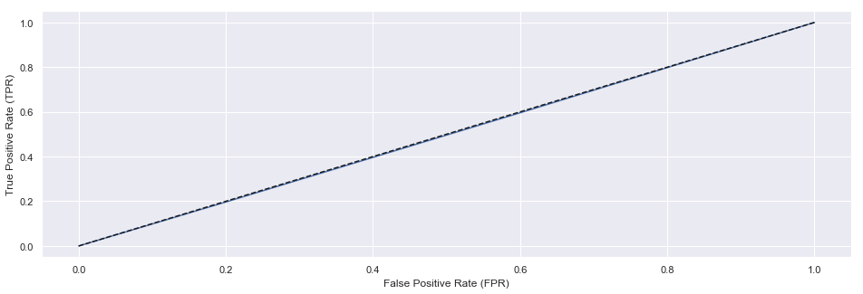

```
Area under the Curve (AUC) of Best Model:
AUC: 0.49724335264149633
```

```python
# use logistic regression model
# (specify solver to avoid warnings)
# (increase max_iter to ensure convergence)
log_reg = LogisticRegression(
    solver='liblinear',
    max_iter=10000
)

# specify parameter grid
# - alpha: constant that multiplies L1/L2-penalty terms
# - l1_ratio: mixing parameter
param_grid = {
    'penalty': ['l1', 'l2'],
    'C': [0.0001, 0.001, 0.01, 0.1, 0.2, 0.3, 0.5, 0.7, 1.0, 1.5, 2.0, 5.0]
}

# specify grid search
grid = GridSearchCV(
    estimator=log_reg,          # estimator to use
    param_grid=param_grid,      # parameters to do grid search over
    scoring='f1',               # use F1 score to evaluate models
    n_jobs=-1,                  # use all cores
    iid=True,                   # assume data was i.i.d. (to avoid warning)
    cv=10,                      # use stratified 10-fold CV
    refit=True,                 # re-fit best model
    verbose=0,                  # do not print training progress
    return_train_score=True     # save training scores
)

# train with grid-search
grid.fit(X, y)
print('')

# report best hyperparameters
print('Best Hyperparameters:')
print(grid.best_params_)
print('')

# report the best score
print('Best Score:')
print(grid.best_score_)
print('')

# keep track of best model
best_model = grid.best_estimator_

# print ROC curve
y_pred = cross_val_predict(best_model, X, y, method='decision_function', cv=10)
fpr, tpr, thresholds = roc_curve(y, y_pred)
plt.plot(fpr, tpr)
plt.plot([0,1],[0,1],'k--')
plt.xlabel('False Positive Rate (FPR)')
plt.ylabel('True Positive Rate (TPR)')
plt.show()

# print area under the curve (AUC) score
auc = roc_auc_score(y, y_pred)
print('Area under the Curve (AUC) of Best Model:')
print('AUC: '+str(auc))
print('')
```

## Exercise 7

**Q:** Make a new dataframe where each sentence (of each case) is treated as a separate document. Compute vader compound sentiment scores for each sentence and report the top 10 highest- and lowest-sentiment sentences.

```python
# build data frame for sentences
columns = [
    'sentence',
    'sentiment_score',
    'cluster'
]
sent_data = pd.DataFrame(columns=pd.Index(columns, name='attributes'))

# set data frame data types
sent_data[['sentiment_score']] = sent_data[['sentiment_score']].astype(float)
sent_data[['cluster']] = sent_data[['cluster']].astype(int)

# gets sentences of a document
def get_sentences(doc):
    sentences = []
    for sentence in doc.sents:
        # replace newlines with spaces
        sentence = sentence.text.replace('\r', ' ').replace('\n', ' ')
        sentences.append(sentence)
    return sentences

# extract sentences from previously processed data
sentences = data['doc'].swifter.apply(get_sentences)

# store sentences into data frame
sent_data['sentence'] = list(itertools.chain.from_iterable(sentences.values))

# print data types
print('Dataframe Data Types:')
print(sent_data.dtypes)
print('')

# print preview of data to show that it's loaded
print('Dataframe Data:')
print(sent_data.head())
print('')

# create sentiment intensity analyzer
sid = SentimentIntensityAnalyzer()

# get the compound polarity score for a sentence
def get_compound_polarity_score(sentence):
    scores = sid.polarity_scores(sentence)
    compound_score = scores['compound']
    return compound_score

# compute the sentiment score for all sentences in data
sent_data['sentiment_score'] = \
    sent_data['sentence'].swifter.apply(get_compound_polarity_score)

# sort sentences by sentiment score
sent_data = sent_data.sort_values(by=['sentiment_score'], ascending=False)

def print_sentences(sents):
    for idx, row in sents.iterrows():
        print('(Score: '+str(row['sentiment_score'])+') '+str(row['sentence']))
        print('')
    print('')
```

```
Dataframe Data Types:
attributes
sentence            object
sentiment_score    float64
cluster            float64
dtype: object

Dataframe Data:
attributes                                           sentence  \
0                       OPINION D. W. NELSON , Circuit Judge:
1           The Native Village of Venetie Tribal Governmen...
2           We have jurisdiction pursuant to 28 U.S.C. 129...
3           We conclude that the Alaska Native Claims Sett...
4           FACTUAL AND PROCEDURAL BACKGROUND This case ar...

attributes  sentiment_score  cluster
0                       NaN      NaN
1                       NaN      NaN
2                       NaN      NaN
3                       NaN      NaN
4                       NaN      NaN
```

```python
print('10 Highest Sentiment Sentences:\n')
print_sentences(sent_data.head(10))
```

```
10 Highest Sentiment Sentences:

(Score: 0.9903) The main grounds for recovery thereof, as stated in the petition, are: "That the assessment and collection of said additional income tax was erroneous and illegal in that it is based upon alleged income accruing to the plaintiff from the liquidating dividend upon the dissolution of t…

(Score: 0.9859) In making its Attorney's Fee Ruling, the district court was obliged, pursuant to our decision in Johannssen, to consider each of five factors: (1) the degree of the opposing party's culpability or bad faith; (2) the ability of the opposing party to satisfy an award of attorney's fees…

(Score: 0.9843) Article 9 of that treaty provides as follows: "Mexicans who, in the territories aforesaid, shall not preserve the character of citizens of the Mexican republic, conformably with what is stipulated in the preceding article, shall be incorporated into the union of the United States, an…

(Score: 0.9828) (1) the degree of the opposing party's culpability or bad faith; (2) the ability of the opposing party to satisfy an award; (3) whether an award would deter others acting under similar circumstances; (4) whether the requesting party sought to benefit all participants and beneficiarie…

(Score: 0.9821) The creditor must provide "[a] description or identification of the type of any security interest held or to be retained or acquired by the creditor in connection with the extension of credit, and a clear identification of the property to which the security interest relates If after-…

(Score: 0.9798) 746 , the Supreme Court cites Greenleaf-Johnson Lumber Co. v. Garrison , supra , Philadelphia Co. v. Stimson , supra , and Willink v. United States , supra , in support of the general rule "that private ownership of property in the beds and waters of navigable streams is subject to t…

(Score: 0.9796) In connection with the land trust, in order to satisfy the trust regulations, the OIN has posted letters of credit securing the payment of all taxes, penalties, and interest determined by the courts to be due on the land at issue and has agreed to supplement or replace those letters …

(Score: 0.9791) The amount paid for fees included in (3) was for the following services as set forth in the stipulation of the parties: "For services in considering the tax problems resulting from the expiration of the trust, advice as to the present status of the Trust for tax purposes, and as to v…

(Score: 0.9786) We have articulated several factors as relevant to the determination of whether such a waiver is knowing and voluntary: 1) the plaintiffs education and business experience, 2) the amount of time the plaintiff had possession of or access to the agreement before signing it, 3) the role…

(Score: 0.9783) The trusts of which the petitioner was trustee were family trusts of the ordinary type and though the testator gave to the trustee broad powers of investment and reinvestment and authority to retain any of the testator's investments, he added the caution "to be more careful as to the…
```

```python
print('10 Lowest Sentiment Sentences:\n')
print_sentences(sent_data.tail(10))
```

```
10 Lowest Sentiment Sentences:

(Score: -0.9819) The provisions of Subpart C mandate alcohol and drug testing for all covered employees involved in various events, including: major train accidents (involving a fatality, release of hazardous material with either evacuation or injury, or $500,000 damage to railroad property); impact…

(Score: -0.9844) Nijhawan, who was the Deputy General Manager of Allied Deals, Inc., was listed in Count 1, the overall conspiracy count that contained the general loss allegation as to the entire fraud scheme and involved conspiracy to commit bank fraud, mail fraud, and wire fraud in violation of 1…

(Score: -0.9846) (1982); one count of participating in a racketeering enterprise, in violation of 18 U.S.C. 1962(c) (1982); 16 counts of mail fraud, in violation of 18 U.S.C. 1341 (1982); one count of wire fraud, in violation of 18 U.S.C. 1343 (1982); eight counts of extortion, in violation of 18 U.…

(Score: -0.985) Specifically, such an expert could have explained to the jury the psychological impact on Belmontes of his father's severe alcoholism; of witnessing [**19] severe domestic violence between his parents; of his family's poverty; of observing his mother's profligate sexual activity; of …

(Score: -0.9861) Because the substantial mitigating evidence that counsel failed to uncover and present to the jury would have been highly beneficial to Belmontes, because counsel's failure to adequately prepare the witnesses who did testify rendered their testimony of little value and sometimes cou…

(Score: -0.9868) Quite similar to the wrongful death statute of Oklahoma, supra , at the time of the airplane crash referred to herein, it was provided by statute in Missouri that when the death of a person was caused by a wrongful act, neglect, or default of another, and such act, neglect, or defau…

(Score: -0.987) The seemingly unusual result is that anyone who transfers intrastate a firearm (which has not been in interstate commerce) knowing it will be used in a crime of violence in that state commits a federal crime even though the crime of violence is not a federal offense, but the party pe…

(Score: -0.9872) Under Washington law, [i]t is a complete defense to any action for damages for personal injury or wrongful death that the person injured or killed was engaged in the commission of a felony at the time of the occurrence causing the injury or death and the felony was a proximate cause…

(Score: -0.9914) That within two or three days thereafter the appellants selected named persons to represent them and authorized such persons to investigate the fire and make estimates as to the value of the property destroyed and settle for the loss; that these adjusters for the insurers visited th…

(Score: -0.9924) Under Virginia law the death penalty may be imposed upon a defendant if the jury finds beyond a reasonable doubt that "there is a probability based upon evidence of the prior history of the defendant or of the circumstances surrounding the commission of the offense of which he is ac…
```

```python
# re-sort data according to index
sent_data = sent_data.sort_index()
```

## Exercise 8

**Q:** Use TfidfVectorizer to compute tf-idf frequencies for each sentence, and then compute cosine similarities between all sentences. Report example pairs of very similar sentences and very dissimilar sentences.

```python
# convert the collection of raw sentences to a matrix of TF-IDF features
tfidf = TfidfVectorizer(
    strip_accents='ascii',  # only consider ascii characters
    lowercase=True,         # convert text to lowercase
    stop_words='english',   # use english stop words
    ngram_range=(2, 3),     # consider (2 to 3)-grams for embeddings
    max_df=0.5,             # ignore terms that are in more than 50% of docs
    min_df=0.001,           # ignore terms that are in less than .1% of docs
    max_features=1000,      # only consider top 1000 terms (w.r.t. term freq.)
    binary=False,           # do not use binary counts (use integer counts)
    norm='l2',              # each sentence-embedding will have unit-norm
    use_idf=True,           # enables inverse-doc-freq weighting
)

# fit TF-IDF Vectorizer
X = tfidf.fit_transform(sent_data['sentence'])

# print embedding dimensions
print('Embedding Dimensionality Chosen by TfidfVectorizer: '+str(X.shape[1]))

# compute the pairwise cosine similarirties
S = cosine_similarity(X, X)

def largest_indices(arr, n):
    """Returns the n largest indices from a numpy array."""
    flat = arr.flatten()
    indices = np.argpartition(flat, -n)[-n:]
    indices = indices[np.argsort(-flat[indices])]
    return np.unravel_index(indices, arr.shape)
```

```
Embedding Dimensionality Chosen by TfidfVectorizer: 144
```

```python
# reduce size of S for efficiency reasons
max_idx = min(1000, S.shape[0])
S = S[0:max_idx,0:max_idx]
```

```python
# report an example of very similar sentences
most_sim_idx = \
    np.unravel_index(np.argmax(S, axis=None), S.shape)
print('Two very similar sentences are ' + str(most_sim_idx) +
      ' with similarity '+str(S[most_sim_idx])+'\n')
print(str(most_sim_idx[0])+": "+sent_data.iloc[most_sim_idx[0]]['sentence']+'\n')
print(str(most_sim_idx[1])+": "+sent_data.iloc[most_sim_idx[1]]['sentence'])
```

```
Two very similar sentences are (81, 81) with similarity 1.0000000000000002

81: Drawing upon the Eighth Circuit's decision in United States v. South Dakota , 665 F.2d 837 (8th Cir.1981), cert.

81: Drawing upon the Eighth Circuit's decision in United States v. South Dakota , 665 F.2d 837 (8th Cir.1981), cert.
```

```python
# report an example of very dissimilar sentences
most_dissim_idx = np.unravel_index(np.argmin(S, axis=None), S.shape)
print('Two very dissimilar sentences are ' + str(most_dissim_idx) +
      ' with similarity '+str(S[most_dissim_idx])+":"+'\n')
print(str(most_dissim_idx[0])+": "+sent_data.iloc[most_dissim_idx[0]]['sentence']+'\n')
print(str(most_dissim_idx[1])+": "+sent_data.iloc[most_dissim_idx[1]]['sentence'])
```

```
Two very dissimilar sentences are (0, 1) with similarity 0.0:

0:  OPINION D. W. NELSON , Circuit Judge:

1: The Native Village of Venetie Tribal Government appeals the district court's determination that the Alaska Native Claims Settlement Act extinguished Indian country in Alaska, and that the tribal government therefore lacks the authority to impose its Business Activities Tax upon a state contractor…
```

## Exercise 9

**Q:** Use k-means clustering to assign the sentences into 20 clusters. List 5 example sentences from each cluster.

```python
# build k-means model (with k=20)
num_clusters = 20
km = KMeans(n_clusters=num_clusters, n_jobs=-1)

# fit k-means model to sentences
km.fit(X)

# get the cluster centers
V = km.cluster_centers_

# add cluster labels to data
cluster_labels = km.labels_.tolist()
sent_data['cluster'] = cluster_labels

# list 5 sentences from each cluster
for cluster_idx in range(0, 20):
    cluster_members = sent_data[sent_data['cluster'] == cluster_idx]
    print('Members of Cluster '+str(cluster_idx)+':')
    for idx, row in cluster_members.head(5).iterrows():
        print(row['sentence'])
    print('')
```

```
Members of Cluster 0:
We conclude that the Alaska Native Claims Settlement Act did not extinguish Indian country in Alaska as a general matter, and that the land Venetie occupies is Indian country.
FACTUAL AND PROCEDURAL BACKGROUND This case arises from Venetie's attempt to impose its Business Activities Tax upon the Neeser Construction Company, which had been hired by the State of Alaska to build a new school in the village.
The Neets'aii Gwich'in--from whom nearly all of the inhabitants of Venetie descend--are a group of Alaska Natives that has historically inhabited an area consisting of the East Fork of the Chandalar River.
In 1940, the Neets'aii Gwich'in adopted a constitution under the Indian Reorganization Act, 25 U.S.C. 476 .
This constitution established the Native Village of Venetie as the governing authority of the Neets'aii Gwich'in.

Members of Cluster 1:
Congress clarified that ANCSA did not "relieve, replace, or diminish any obligation of the United States or of the State or [sic] Alaska to protect and promote the rights or welfare of Natives " 43 U.S.C. 1601(c) .
The United States conveyed title to the former Venetie Reservation to the Venetie Indian Corporation and the Neets'aii Corporation as tenants in common.
P. 52(a) ; United States v. American Prod.
; see United States v. John , 437 U.S. 634, 649 , 98 S.Ct.
United States v. Pelican , 232 U.S. 442, 449 , 34 S.Ct. 396, 399 , 58 L.Ed.

Members of Cluster 2:
The Native Village of Venetie Tribal Government appeals the district court's determination that the Alaska Native Claims Settlement Act extinguished Indian country in Alaska, and that the tribal government therefore lacks the authority to impose its Business Activities Tax upon a state contractor.
We have jurisdiction pursuant to 28 U.S.C. 1291 , and we reverse the district court's judgment.
The district court issued a preliminary injunction enjoining the Tribe from further enforcement proceedings.
The court articulated a six-part test to guide the district court in its determination of the Indian country question.
First, Venetie contends that the district court applied an unduly restrictive standard to determine whether the land at issue is Indian country.

Members of Cluster 3:
State of Alaska v. Native Village of Venetie , 856 F.2d 1384 (9th Cir.1988)
Hopi Tribe v. Navajo Tribe , 46 F.3d 908, 921 (9th Cir.), cert.
(9th Cir.1995).
138 (1918); see also Rumsey Indian Rancheria of Wintun Indians v. Wilson , 64 F.3d 1250, 1257 (9th Cir.1994); McNabb v. Bowen , 829 F.2d 787, 792 (9th Cir.1987).
Pence v. Kleppe , 529 F.2d 135, 138 n. 5 (9th Cir.1976); Cohen, supra, at 739 .

Members of Cluster 4:
denied , 451 U.S. 941 , 101 S.Ct.
denied , 405 U.S. 989 , 92 S.Ct. 1251 , 31 L.Ed.2d 455 (1972), whose reasoning we adopt here: Accord , United Gas Pipeline Co. v. Mobile Gas Service Corp. , 350 U.S. 332, 347 ,
Fuentes v. Shevin , 407 U.S. 67, 85 , 92 S.Ct.
Id. at 90-91 , 92 S.Ct.
Id. at 91 , 92 S.Ct.

Members of Cluster 5:
Although the Supreme Court has never resolved this narrow question, we do not write on a blank slate.
This construction accords with the Supreme Court cases upon which 1151 is based, see Reviser's Note, 1948 Act, 18 U.S.C.A. 1151 : United States v. Sandoval , 231 U.S. 28 , 34 S.Ct. 1 , 58 L.Ed. 107
Proof that federal superintendence is "pervasive" has never been required by the Supreme Court.
Such a rule would also violate principles articulated by the Supreme Court in another early Indian country case, United States v. Chavez , 290 U.S. 357, 364 , 54 S.Ct.
```

[output cut: 84 more lines]

```
And in construing the Merchant Marine Act here under consideration the Supreme Court has held stevedores to be seamen within the meaning of the act because engaged in maritime service formerly rendered by the ship's crew.

Members of Cluster 18:
Indeed, the court concluded that a finding of a dependent Indian community requires a showing of these two factors, along with proof that the Native group in question is a tribe.
The court concluded that the corporate model of land ownership dictated by the Act evinced a congressional intent to treat Alaska Natives as ordinary business entities--not Natives, "as such."
The court concluded that "it would be anomalous to adopt the State's position suggesting that the treaties conferring upon the Creek Nation a title stronger than the right of occupancy have left the tribal land base with less protection, simply because fee title is not formally held by the United St…
The district court concluded that "[t]he federal government no longer exercises that level of active superintendence necessary to evidence an intent to be the dominant political institution in the area in question to the exclusion of the state."
The district court concluded, however, that the land at issue is no longer set aside for the use and occupancy of Alaska Natives, as such.

Members of Cluster 19:
In 1971, Congress passed the Alaska Native Claims Settlement Act ("ANCSA"), 43 U.S.C. 1601 et seq.
This is a proceeding under Chapter X of the Bankruptcy Act (11 U.S.C. 501 et seq.)
299, 317 et seq.,
This is an appeal by the Environmental Protection Agency (EPA) from the district court's dismissal of its enforcement action under the Clean Air Act, 42 U.S.C. 7401 et seq.
PANE contends that, under the National Environmental Policy Act (NEPA), 42 U.S.C. 4321 et seq.
```